# Exploratory Data Analysis for Video Game Development Companies Ryan Reiser

## This analysis examines the stock data of four major video game development companies across the world from January 1st, 2010 to August 31st, 2024. Analyzed companies include Tencent (China), Sony (Japan), Electronic Arts (USA), and Ubisoft (France). I chose to analyze these companies because I find the gaming industry very interesting in that it often shows trends differing from most other companies, so I chose to view some of the largest publicly traded video game development companies to view. I also wanted to specifically view companies from different countries and cultures to view how that would affect the industry.

```python
import yfinance as yf
import pandas as pd

# Define the ticker symbols for the companies
tickers = ['TCEHY', 'SONY', 'EA', 'UBSFY']  # Tencent (China), Sony (Japan), Electronic Arts (USA), Ubisoft (France)

# Set the start and end dates
start_date = '2010-01-01'
end_date = '2024-08-31'

# Initialize an empty DataFrame for storing stock data
stock_prices = pd.DataFrame()

# Fetch and merge the adjusted close prices for each ticker
for ticker in tickers:
    # Fetch the data
    data = yf.download(ticker, start=start_date, end=end_date, progress=False)
    # Resample the data to get the monthly adjusted close prices
    monthly_data = data['Adj Close'].resample('ME').last()
    # Convert the Series to DataFrame and rename the column to the ticker name
    monthly_data = pd.DataFrame(monthly_data)
    monthly_data.columns = [ticker]
    # Merge with the main DataFrame
    if stock_prices.empty:
        stock_prices = monthly_data
    else:
        stock_prices = stock_prices.join(monthly_data, how='outer')

# Display the first few rows of the DataFrame
print(stock_prices.head())
```

```
               TCEHY       SONY         EA     UBSFY
Date
2010-01-31  3.394330  29.390402  15.923065  2.733077
2010-02-28  3.522520  30.168728  16.216486  2.554185
2010-03-31  3.627239  34.015110  18.250889  2.633693
2010-04-30  3.735569  30.375711  18.945318  2.574062
2010-05-31  3.484334  27.322165  16.148027  1.848554
```

## The code downloads the corresponds tickers for each company from the yfinance library, resamples the data to obtain the monthly adjusted close prices, and converts the data into a Pandas DataFrame for easy analysis.

```python
# Renames the columns from ticker symbols to company names

stock_prices.columns = ['Tecent (China)', 'Sony (Japan)', 'Electronic Arts (USA)', 'Ubisoft (France)']
```

```python
stock_prices.tail()
```

| Date | Tecent (China) | Sony (Japan) | Electronic Arts (USA) | Ubisoft (France) |
| --- | --- | --- | --- | --- |
| 2024-04-30 | 43.382523 | 82.570000 | 126.476265 | 4.68 |
| 2024-05-31 | 46.529999 | 82.339996 | 132.710800 | 4.82 |
| 2024-06-30 | 47.360001 | 84.949997 | 139.152573 | 4.32 |
| 2024-07-31 | 46.049999 | 88.589996 | 150.747803 | 4.05 |
| 2024-08-31 | 48.509998 | 97.559998 | 151.820007 | 3.76 |

## Displays most recent stock prices for each comapny

```python
stock_prices.describe()
```

|  | Tecent (China) | Sony (Japan) | Electronic Arts (USA) | Ubisoft (France) |
| --- | --- | --- | --- | --- |
| count | 176.000000 | 176.000000 | 176.000000 | 176.000000 |
| mean | 29.105236 | 47.848018 | 78.611792 | 7.869910 |
| std | 20.385822 | 30.719462 | 46.770197 | 6.015187 |
| min | 3.002863 | 9.015063 | 10.778391 | 1.063415 |
| 25% | 9.330123 | 22.630968 | 24.711078 | 2.732308 |
| 50% | 27.658521 | 34.536722 | 86.080414 | 5.630000 |
| 75% | 43.712784 | 77.133202 | 123.383465 | 13.437500 |
| max | 82.871140 | 124.358925 | 151.820007 | 22.049999 |

## Displays commonly used descriptive statistics such as mean, minimum, and maximum stock prices for each company over the timeline

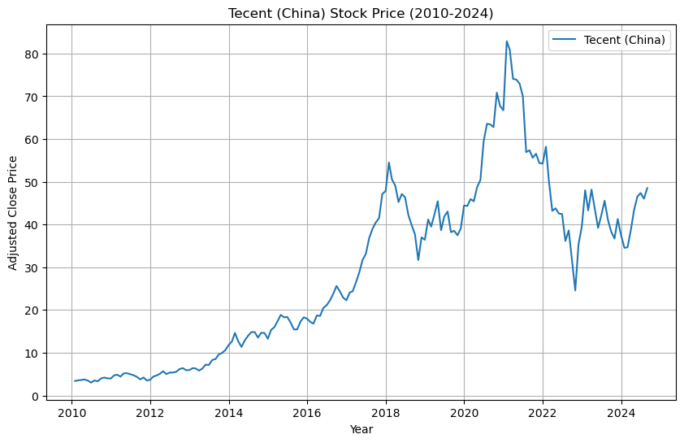

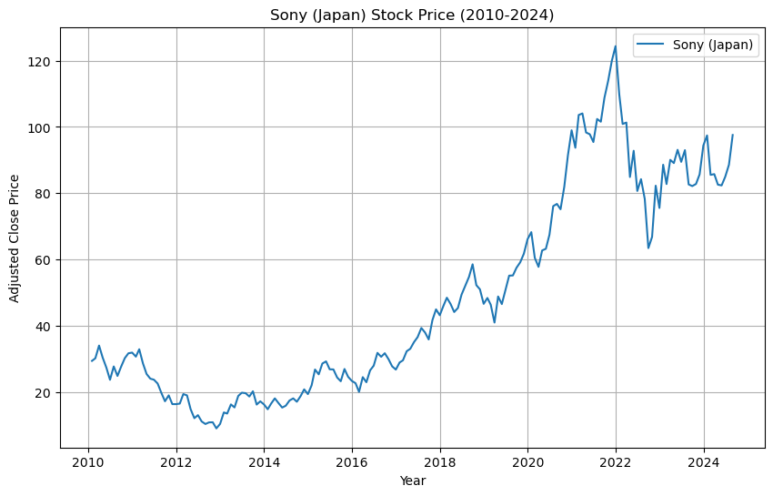

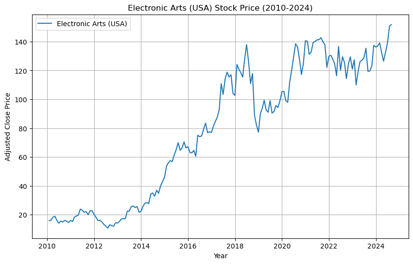

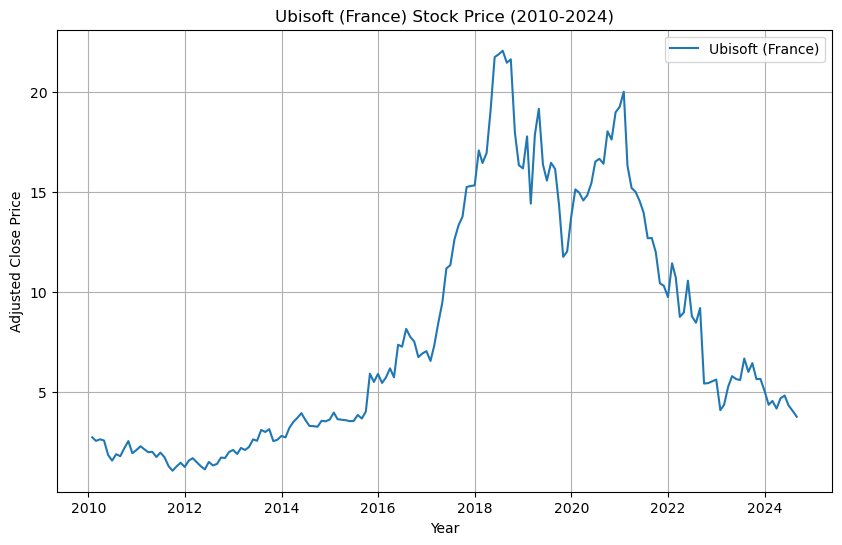

```python
import matplotlib.pyplot as plt

for column in stock_prices.columns:
    plt.figure(figsize=(10, 6))  # Set the figure size for better readability
    plt.plot(stock_prices.index, stock_prices[column], label=column)
    plt.title(f'{column} Stock Price (2010-2024)')
    plt.xlabel('Year')
    plt.ylabel('Adjusted Close Price')
    plt.legend()
    plt.grid(True)
    plt.show()
```

## Displays plots of adjusted close price for each company stock over the 2010-2024 timeline.

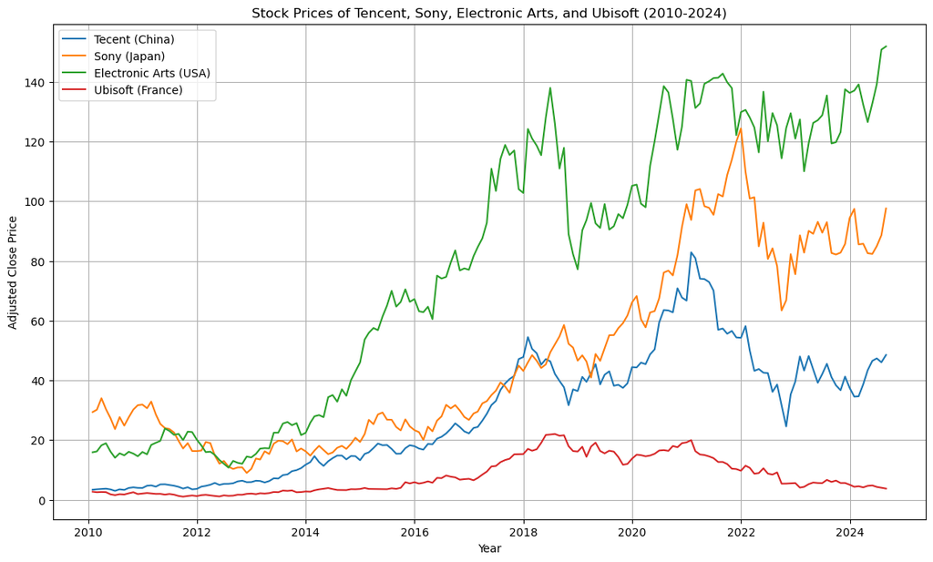

```python
# Set the figure size for better readability
plt.figure(figsize=(14, 8))

# Plot each column in the DataFrame
for column in stock_prices.columns:
    plt.plot(stock_prices.index, stock_prices[column], label=column)

# Set the title and labels
plt.title('Stock Prices of Tencent, Sony, Electronic Arts, and Ubisoft (2010-2024)')
plt.xlabel('Year')
plt.ylabel('Adjusted Close Price')

# Add legend to identify each line
plt.legend()

# Enable grid for better readability
plt.grid(True)

# Show the plot
plt.show()
```

```python
stock_prices.corr()
```

|  | Tecent (China) | Sony (Japan) | Electronic Arts (USA) | Ubisoft (France) |
| --- | --- | --- | --- | --- |
| Tecent (China) | 1.000000 | 0.850136 | 0.920228 | 0.796266 |
| Sony (Japan) | 0.850136 | 1.000000 | 0.867818 | 0.482502 |
| Electronic Arts (USA) | 0.920228 | 0.867818 | 1.000000 | 0.688926 |
| Ubisoft (France) | 0.796266 | 0.482502 | 0.688926 | 1.000000 |

## Displays correlation between each company.

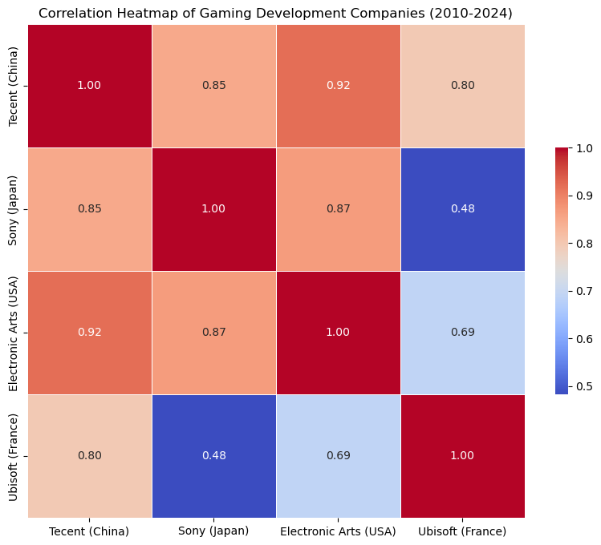

```python
import seaborn as sns
import matplotlib.pyplot as plt

# Calculate the correlation matrix
corr = stock_prices.corr()

# Set up the matplotlib figure
plt.figure(figsize=(10, 8))

# Draw the heatmap with the mask and correct aspect ratio
sns.heatmap(corr, annot=True, fmt=".2f", cmap='coolwarm',
            xticklabels=corr.columns, yticklabels=corr.columns,
            linewidths=.5, cbar_kws={"shrink": .5})

# Set titles and labels
plt.title('Correlation Heatmap of Gaming Development Companies (2010-2024)')
```